# 2_MLPS_R_visualization

Zhe Zhang (TA - Heinz CMU PhD)

1/19/2017

## Lecture 2: Business & Data Understanding

Key specific tasks we covered in this lecture are around exploratory data analysis. * dataset attribute types * working with categorical variables (`factor` variables in R) * data matrix styles (long vs wide) * checking for data quality

- temporal line plot
- bar chart
- histogram and 1-dimensional density visualization (and bin sizes)
- 2-dimensional histograms
- kernel density estimation
- median, quantile, quartile, interquartile range
- box plots
- scatter plots (many plots, overplotting, correlation graphs)
- parallel coordinates
- radar plots

## Dataset Actions

```r
# use the flights dataset
require(tidyverse)
# use `glimpse()` or `str()` to see a dataset's attributes
glimpse(iris)
```

```
## Observations: 150
## Variables: 5
## $ Sepal.Length <dbl> 5.1, 4.9, 4.7, 4.6, 5.0, 5.4, 4.6, 5.0, 4.4, 4.9,...
## $ Sepal.Width  <dbl> 3.5, 3.0, 3.2, 3.1, 3.6, 3.9, 3.4, 3.4, 2.9, 3.1,...
## $ Petal.Length <dbl> 1.4, 1.4, 1.3, 1.5, 1.4, 1.7, 1.4, 1.5, 1.4, 1.5,...
## $ Petal.Width  <dbl> 0.2, 0.2, 0.2, 0.2, 0.2, 0.4, 0.3, 0.2, 0.2, 0.1,...
## $ Species      <fctr> setosa, setosa, setosa, setosa, setosa, setosa, ...
```

```r
glimpse(mtcars)
```

```
## Observations: 32
## Variables: 11
## $ mpg  <dbl> 21.0, 21.0, 22.8, 21.4, 18.7, 18.1, 14.3, 24.4, 22.8, 19....
## $ cyl  <dbl> 6, 6, 4, 6, 8, 6, 8, 4, 4, 6, 6, 8, 8, 8, 8, 8, 8, 4, 4, ...
## $ disp <dbl> 160.0, 160.0, 108.0, 258.0, 360.0, 225.0, 360.0, 146.7, 1...
## $ hp   <dbl> 110, 110, 93, 110, 175, 105, 245, 62, 95, 123, 123, 180, ...
## $ drat <dbl> 3.90, 3.90, 3.85, 3.08, 3.15, 2.76, 3.21, 3.69, 3.92, 3.9...
## $ wt   <dbl> 2.620, 2.875, 2.320, 3.215, 3.440, 3.460, 3.570, 3.190, 3...
## $ qsec <dbl> 16.46, 17.02, 18.61, 19.44, 17.02, 20.22, 15.84, 20.00, 2...
## $ vs   <dbl> 0, 0, 1, 1, 0, 1, 0, 1, 1, 1, 1, 0, 0, 0, 0, 0, 0, 1, 1, ...
## $ am   <dbl> 1, 1, 1, 0, 0, 0, 0, 0, 0, 0, 0, 0, 0, 0, 0, 0, 0, 1, 1, ...
## $ gear <dbl> 4, 4, 4, 3, 3, 3, 3, 4, 4, 4, 4, 3, 3, 3, 3, 3, 3, 4, 4, ...
## $ carb <dbl> 4, 4, 1, 1, 2, 1, 4, 2, 2, 4, 4, 3, 3, 3, 4, 4, 4, 1, 2, ...
```

When your data has categorical values, if dataset has already been cleaned, you may not need to do much with it except be aware of it. When there are issues or things you’d like to change about your categorical variables, use the `forcats` package. Also, it can help reduce errors to not use factors in the first place, the `tidyverse` packages should work just as well with text/character variables versus factors. To convert a column to a factor use `{r} df$factor_column <- as.factor(df$factor_column)`.

To convert a dataset between a “wide” format and a “long” format, use the `gather` and `spread` functions available in the tidyr package. See more here: http://r4ds.had.co.nz/tidy-data.html#tidy-data-1

```r
library(tidyverse)

table4a
```

```
## # A tibble: 3 × 3
##       country `1999` `2000`
## *       <chr>  <int>  <int>
## 1 Afghanistan    745   2666
## 2      Brazil  37737  80488
## 3       China 212258 213766
```

```r
# renaming to avoid the weird columns that start with numbers
renamed_table4a <- table4a %>% rename('yr_1999' = `1999`, 'yr_2000' = `2000`)

# gather the data to make it long and make each row an observation
renamed_table4a %>%
  gather(yr_1999, yr_2000, key = "year", value = "cases")
```

```
## # A tibble: 6 × 3
##       country    year  cases
##         <chr>   <chr>  <int>
## 1 Afghanistan yr_1999    745
## 2      Brazil yr_1999  37737
## 3       China yr_1999 212258
## 4 Afghanistan yr_2000   2666
## 5      Brazil yr_2000  80488
## 6       China yr_2000 213766
```

See here http://r4ds.had.co.nz/tidy-data.html#spreading for more information on making data from long to wide.

To check for data quality and potential missing variables, two keys options are summarization and visualization (and both combined). We discuss visualization below. This will not catch all potential errors, but is a way to start. This is especially useful when you have subgroups or categorical variables from which to compare. This chapter covers a lot of the EDA that we talked about in class in R: http://r4ds.had.co.nz/exploratory-data-analysis.html

```r
library(dplyr)
library(nycflights13)

by_day <- group_by(flights, year, month, day)
summarise(by_day, delay = mean(dep_delay, na.rm = TRUE))
```

```
## Source: local data frame [365 x 4]
## Groups: year, month [?]
##
##     year month   day     delay
##    <int> <int> <int>     <dbl>
## 1   2013     1     1 11.548926
## 2   2013     1     2 13.858824
## 3   2013     1     3 10.987832
## 4   2013     1     4  8.951595
## 5   2013     1     5  5.732218
## 6   2013     1     6  7.148014
## 7   2013     1     7  5.417204
## 8   2013     1     8  2.553073
## 9   2013     1     9  2.276477
## 10  2013     1    10  2.844995
## # ... with 355 more rows
```

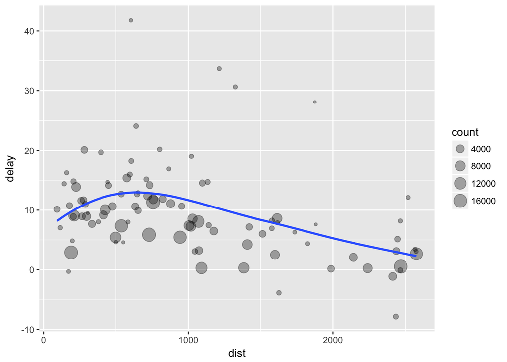

```r
by_dest <- group_by(flights, dest)
delay <- summarise(by_dest,
  count = n(),
  dist = mean(distance, na.rm = TRUE),
  delay = mean(arr_delay, na.rm = TRUE)
)
delay <- filter(delay, count > 20, dest != "HNL")

# It looks like delays increase with distance up to ~750 miles
# and then decrease. Maybe as flights get longer there's more
# ability to make up delays in the air?
ggplot(data = delay, mapping = aes(x = dist, y = delay)) +
  geom_point(aes(size = count), alpha = 1/3) +
  geom_smooth(se = FALSE)
```

```r
# cite: R4DS
```

## Visualization Actions

The R4DS has more examples and a thorough discussion of both visualization and especially, important, how to use visualization for exploratory analysis, which is focus of the early part of this course. I highly recommend reading through these two sections and looking at the examples. If you’re not already comfortable with the pieces, doing so will be quite helpful for all your work in this class and going forward with R and analysis. I will only briefly touch on the specific commands below.

- http://r4ds.had.co.nz/data-visualisation.html
- http://r4ds.had.co.nz/exploratory-data-analysis.html

We recommend the use of the `ggplot2` package in this class. It has a consistent and clear syntax that helps you think about what data you’re interested in visualizing. The R4DS book has a deeper explanation.

Basic graphics in `ggplot2` are a combination of two pieces:

- `ggplot(data = your_data)`
- `geom_SOME_VIZ_TYPE(mapping = aes(x = x_var, y = y_var, color = color_var))`

The `ggplot()` function tells which dataset to use. Then, we can think about each of the following pieces as adding layers to an empty image. You can add a line plot layer, a point layer, a histogram layer, etc. Each layer type will have different arguments, of at least 1 data variable to plot (e.g. histogram). Sometimes, we can make our layers capture additional information by tweaking the layer’s aesthetics (color, size, shape, linetype) by giving them additional variables.

If you want color, size, shape, or linetype to not **vary** based on a data variable, place that option outside of the `aes()` (aesthetics) function call.

Sometimes, you will see the `ggplot()` function contain the aesthetics (as shown in examples below). This means that these will be the default aesthetics that will be passed to all geom_layers. This is useful when we plot several layers together (e.g., a line plot and a point plot together).

```r
# More specific examples of commands incoming
#   mostly based around ggplot2 package
library(tidyverse)
library(ggplot2) # redundant, but here for emphasis

# we'll use the mpg dataset
head(mpg)
```

```
## # A tibble: 6 × 11
##   manufacturer model displ  year   cyl      trans   drv   cty   hwy    fl
##          <chr> <chr> <dbl> <int> <int>      <chr> <chr> <int> <int> <chr>
## 1         audi    a4   1.8  1999     4   auto(l5)     f    18    29     p
## 2         audi    a4   1.8  1999     4 manual(m5)     f    21    29     p
## 3         audi    a4   2.0  2008     4 manual(m6)     f    20    31     p
## 4         audi    a4   2.0  2008     4   auto(av)     f    21    30     p
## 5         audi    a4   2.8  1999     6   auto(l5)     f    16    26     p
## 6         audi    a4   2.8  1999     6 manual(m5)     f    18    26     p
## # ... with 1 more variables: class <chr>
```

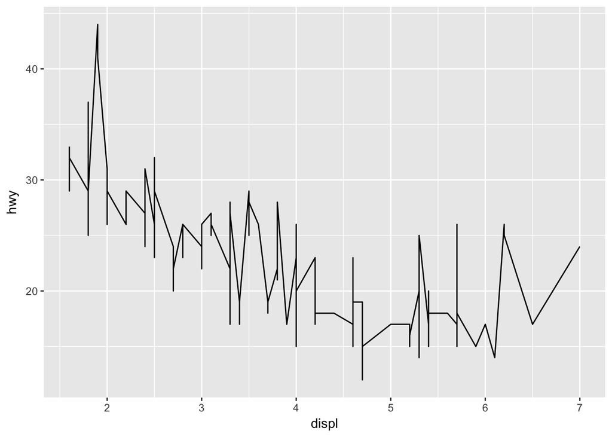

```r
# line plot
ggplot(data = mpg, mapping = aes(x = displ, y = hwy)) +
  geom_line()
```

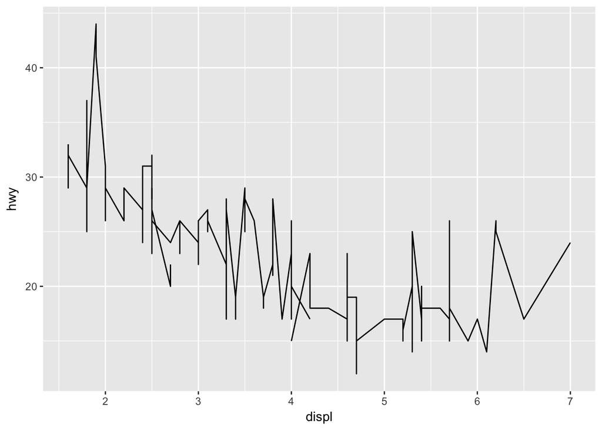

```r
# sometimes we want to group on different categorical variables
ggplot(data = mpg, mapping = aes(x = displ, y = hwy, group = cyl)) +
  geom_line()
```

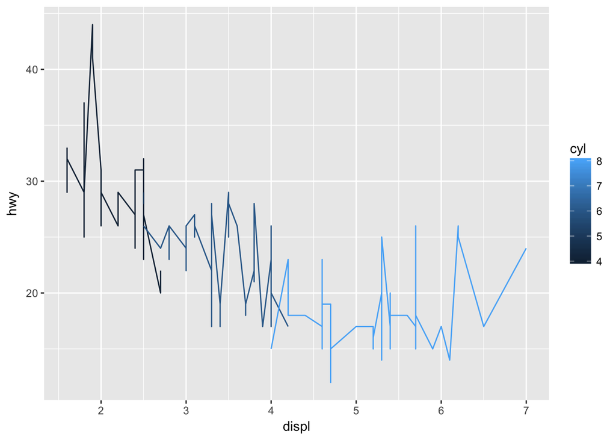

```r
# but we can't tell the lines apart without color
ggplot(data = mpg,
       mapping = aes(x = displ, y = hwy,
                     group = cyl, color = cyl)) +
  geom_line()
```

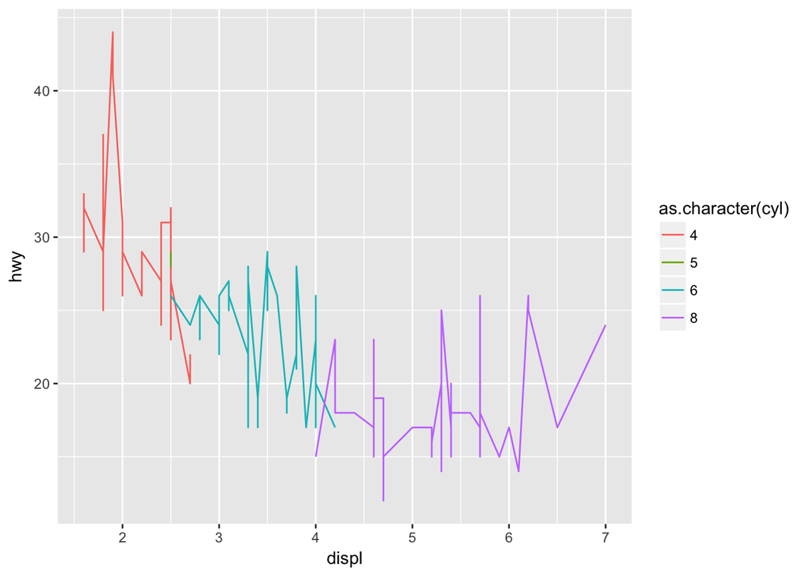

```r
# ggplot is treating CYL as a continuous variable;
#   we want to avoid this
# but we can't tell the lines apart without color
ggplot(data = mpg,
       mapping = aes(x = displ, y = hwy,
                     group = cyl, color = as.character(cyl))) +
  geom_line()
```

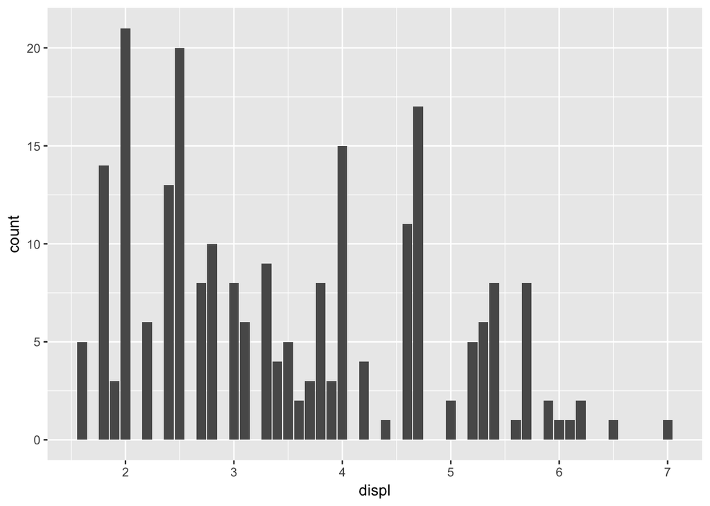

```r
# bar chart (only uses one variable because it counts automatically)
#   IF you want to supply your own count instead, use
#   geom_bar(stat = "identity")
ggplot(mpg, aes(x = displ)) +
  geom_bar()
```

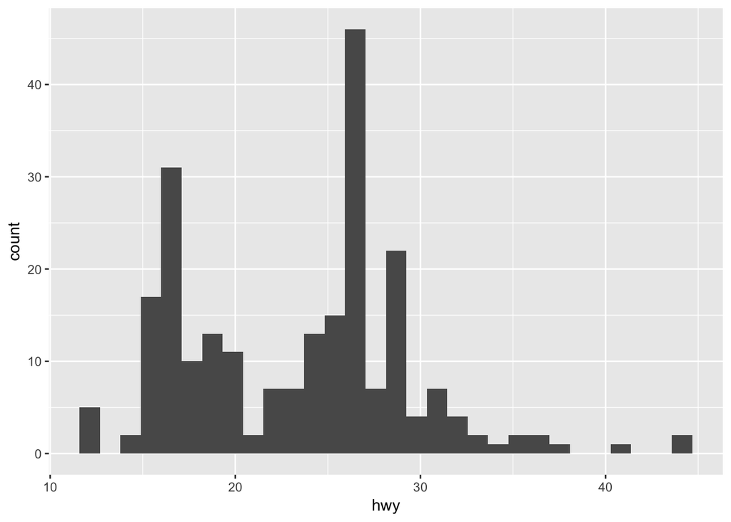

```r
# histogram and 1-dimensional density visualization (and bin sizes)
ggplot(mpg, aes(x = hwy)) +
  geom_histogram()
```

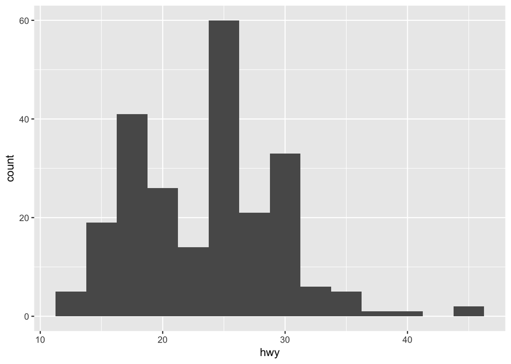

```r
ggplot(mpg, aes(x = hwy)) +
  geom_histogram(binwidth = 2.5)
```

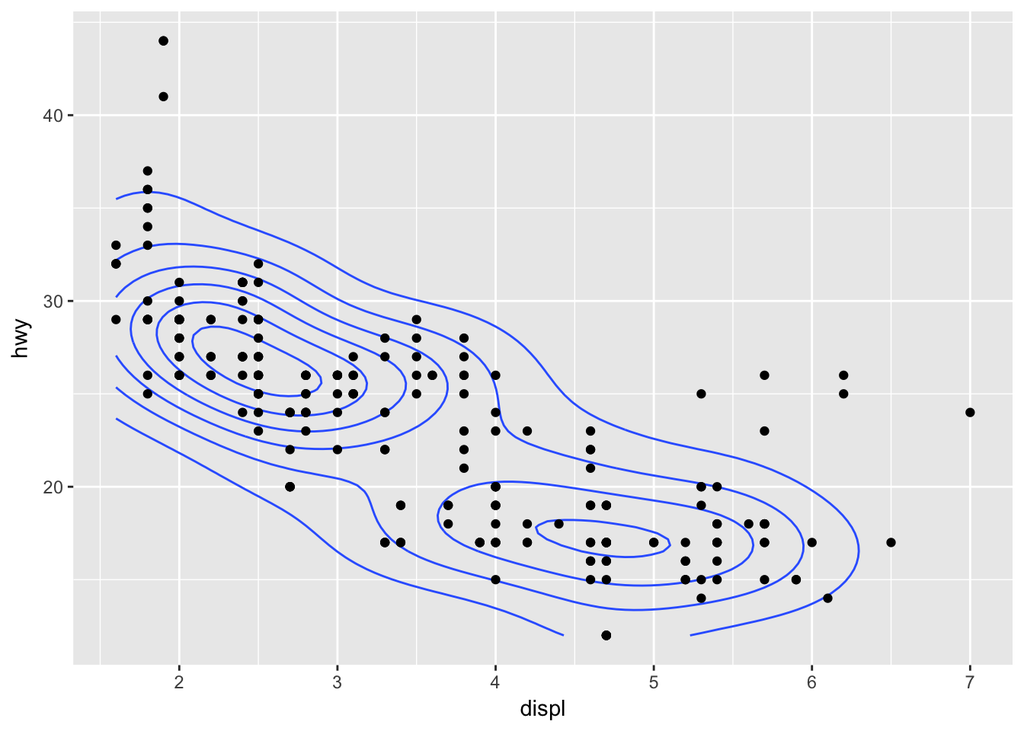

```r
# 2-dimensional histograms/density
ggplot(mpg, aes(x = displ, y = hwy)) +
  geom_density2d() +
  geom_point()
```

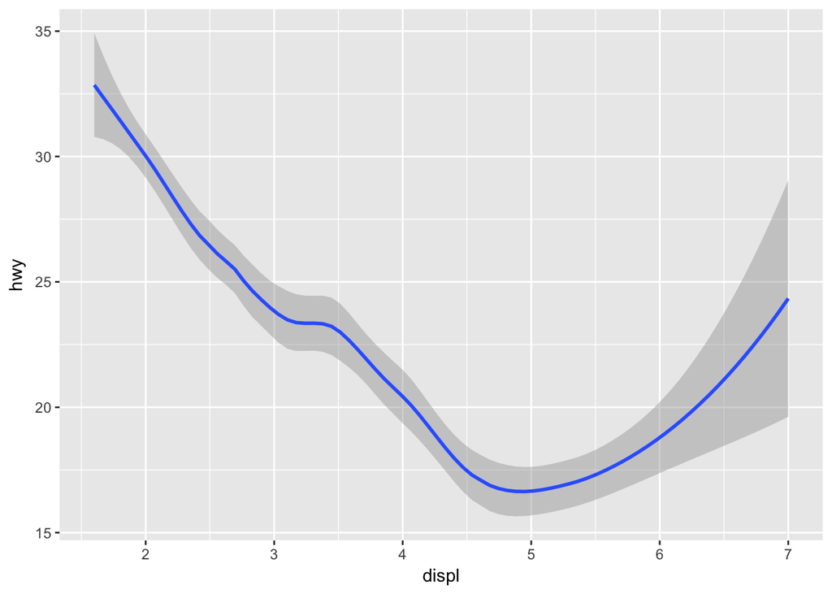

```r
# kernel density estimation
#   we use the built in smoother in ggplot for now
#   GEOM_SMOOTH()
ggplot(data = mpg) +
  geom_smooth(mapping = aes(x = displ, y = hwy),
              method = "loess", span = 0.5)
```

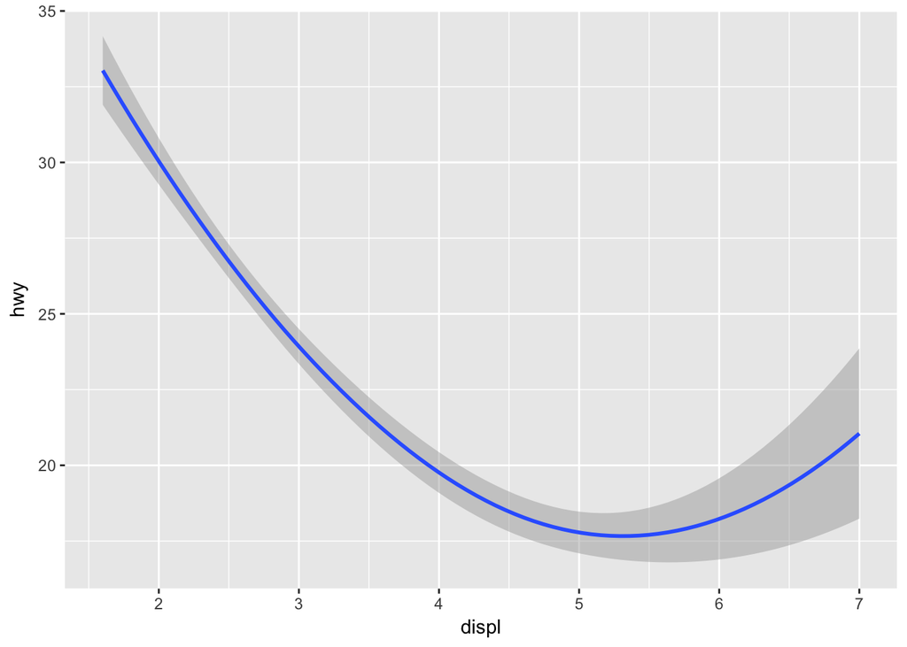

```r
ggplot(data = mpg) +
  geom_smooth(mapping = aes(x = displ, y = hwy),
              method = "loess", span = 2)
```